# BibWrangleR

Brian E. Perron, Ph.D.

December 19, 2014

# Overview

This document provides an overview of a suite of scripts that is designed to facilitate bibliometric analyses of a variety of databases that are not readily amenable to analyses due to the shape of the output. These scripts represent a major advance in bibliometric analyses, because it allows a wide range of journal article meta-data to be analyzed. The scripts *wrangle* the data into proper shape using the R programming language – hence, the name, `BibWrangleR`. Users who are not familiar with the R programming language can easily process the files, which can then be output into a standard *.csv format for analysis in statistical packages like Stata, SAS, and SPSS.

The scripts support the wrangling of three different databases: PubMed, PsychInfo (via EbscoHost), and Citation Reports from Web of Science. In addition to wrangling the output of search results into a shape for easy analysis, functionality is also provided to link the results across multiple databases. Thus, a highly refined search can be performed in PubMed or PsychInfo, and those search results can then be linked to the Citation Reports from Web of Science.

To functionality of the scripts will be demonstrated with a simple research question: To what extent are new or translated measures published in social work journals subsequently used in research? Because this question is an example to show the functionality, this example will focus on all the measures from a single journal, *Research on Social Work Practice*. However, keep in mind that the user can easily scale the search to include as many journals that are indexed by the database being analyzed.

# Step 1. Data Collection

## Obtain Data from PsychInfo (EbscoHost)

The first step of the process is to perform a search on the database of interest. For this example, PsychoInfo is used as the target database. This journal has been indexed in PsychInfo since the journal was initially launched in 1990, so the search within this journal will be comprehensive. A simple EbscoHost query can be performed by specifying the journal using the source (`SO`) operator, followed by a series of other search terms with Boolean operators. It is assumed the reader knows how to perform advanced search queries to narrow results and, therefore, will not be covered here.

After the search is performed in EbscoHost, the search results need to be exported. This is done by selecting the *Share* button, and then *Export results*. The *Export results* gives the user a number of different formatting options for the search results. The required for PsychInfo results (with the EbscoHost system) to be processed by `BibWranglR` must be the *Generic bibliographic management format*. The search results for this example produced 176 unique articles, and the format of the output are a standard text (*.txt) file:

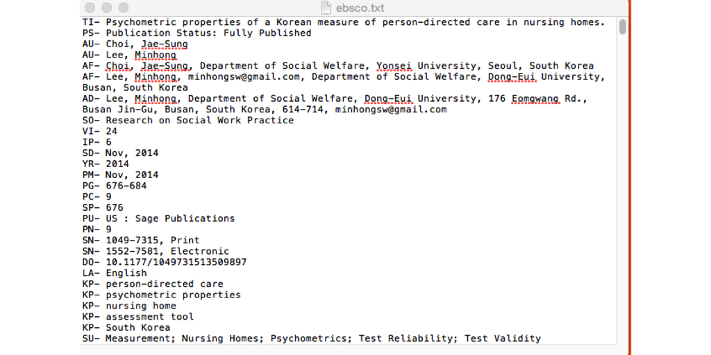

The reader will need to save this *txt file in a folder that does not contain any other* .txt files.

## Obtain Citation Reports (from Web of Science)